# 2018-01-17_European corn borer rearing

Qinwen Xia

2018-01-17

[Back](https://adnguyen.github.io/Hahn_lab_protocols/) to main page

# General info and notes before starting

# Reagents

# Protocol

**Colony:**

We have two strains of ECB in Hahn lab: BE (bivoltine E-strain) and UZ (univoltine Z-strain)

1. Adults: Cages for adults are kept in fly rooms. Separate rooms for each strain. Feed with water https://user-images.githubusercontent.com/31771163/40731419-009f9898-63ff-11e8-94a4-787dd376d184.JPG
2. Egg:

   lay on wax paper. Collect eggs daily and store in containers.

   store at the fly room https://user-images.githubusercontent.com/31771163/40731397-f04bf4e6-63fe-11e8-9e77-98b5c0f8e4d4.JPG
3. Larvae:

   feed on standard artificial diet for ECB larvae (Southland Products, Lake Village, AR, USA)

   grow at 16:8 L:D and 26 °C

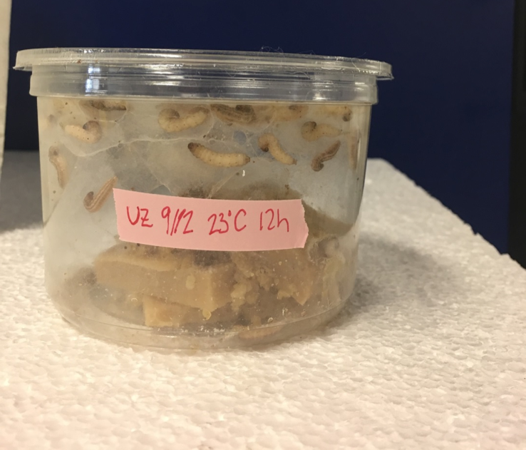

   larvae

4. Pupae

**Experimental rearing:**

1. Diapause induction

   12:12 L:D and 23 °C
2. Diapause termination

   16:8 L:D and 26 °C

   After 46 days in diapause induction condition, transfer diapausing larvae into diapause termination condition.

**Artificial diet**

1. measure 930*2=1860ml water and boil it with kettle https://user-images.githubusercontent.com/31771163/40731461-1c2a52d8-63ff-11e8-8cad-727bd963cc93.JPG
2. weigh 162*2=324g mix powder https://user-images.githubusercontent.com/31771163/40731471-20f6a0c8-63ff-11e8-8346-ef1438c74b18.JPG
3. add boiled water into blender, and turn on the blender, then add mix powder and votex for 4 mins https://user-images.githubusercontent.com/31771163/40731486-26bfbf26-63ff-11e8-8122-840f0e26dbe6.JPG
4. turn off blender and pour into containers https://user-images.githubusercontent.com/31771163/40731495-2e523c64-63ff-11e8-9441-b4621d683be3.JPG
5. keep in friger after cool down